# ACS notebook

Matthew Cvitanovich

This is a proof-of-concept notebook exemplifying how one might obtain estimates of the following probabilities for an individual based on their age (category), sex, and race/ethnicity using data from the [American Census Survey (ACS)](https://www.census.gov/programs-surveys/acs).  
**(1)** highest level of education achieved  
**(2)** having experienced income below/above the Federal poverty level within the preceding 12 months

```r
##################################################################
#                   Define API Requests
##################################################################


# Race/ethnicity-specific proportions of education by (tract, sex)
# ----------------------------------------------------------------
request_ed_by_tract <- function(raceth){
  varlist <- c('C15002A', 'C15002B', 'C15002C', 'C15002D',
               'C15002E', 'C15002F', 'C15002G', 'C15002I')

  names(varlist) <- c('white', 'black', 'alaskan', 'asian',
                      'hawaian', 'other', 'multirace', 'hispanic')

  df <- get_acs(geography = "tract",
                   survey = 'acs5',
                   variables = c(total = paste0(varlist[raceth], "_001"),
                                 # male
                                 male = paste0(varlist[raceth], "_002"),
                                 male_less_hs = paste0(varlist[raceth], "_003"),
                                 male_hs_graduate = paste0(varlist[raceth], "_004"),
                                 male_some_college = paste0(varlist[raceth], "_005"),
                                 male_college_graduate = paste0(varlist[raceth], "_006"),
                                 # female
                                 female = paste0(varlist[raceth], "_007"),
                                 female_less_hs = paste0(varlist[raceth], "_008"),
                                 female_hs_graduate = paste0(varlist[raceth], "_009"),
                                 female_some_college = paste0(varlist[raceth], "_010"),
                                 female_college_graduate = paste0(varlist[raceth], "_011")),
                    state='TX',
                    county='Tarrant',
                    year = 2019,
                    moe_level=95)

  return(df)
}



# Race/ethnicity-specific proportions of age by by (tract, sex)
# -------------------------------------------------------------
# ... B01001A == "Sex by Age" ... with smaller age categories
request_age_by_tract <- function(raceth){
  varlist <- c('B01001A', 'B01001B', 'B01001C', 'B01001D',
               'B01001E', 'B01001F', 'B01001G', 'B01001I')

  names(varlist) <- c('white', 'black', 'alaskan', 'asian',
                      'hawaian', 'other', 'multirace', 'hispanic')

  df <- get_acs(geography = "tract",
                   survey = 'acs5',
                   variables = c(total      = paste0(varlist[raceth], "_001"),
                                 # male
                                 male       = paste0(varlist[raceth], "_002"),
                                 male_25_29 = paste0(varlist[raceth], "_009"),
                                 male_30_34 = paste0(varlist[raceth], "_010"),
                                 male_35_44 = paste0(varlist[raceth], "_011"),
                                 male_45_54 = paste0(varlist[raceth], "_012"),
                                 male_55_64 = paste0(varlist[raceth], "_013"),
                                 male_65_74 = paste0(varlist[raceth], "_014"),
                                 male_75_84 = paste0(varlist[raceth], "_015"),
                                 male_85_pl = paste0(varlist[raceth], "_016"),
                                 # female
                                 female       = paste0(varlist[raceth], "_017"),
                                 female_25_29 = paste0(varlist[raceth], "_024"),
                                 female_30_34 = paste0(varlist[raceth], "_025"),
                                 female_35_44 = paste0(varlist[raceth], "_026"),
                                 female_45_54 = paste0(varlist[raceth], "_027"),
                                 female_55_64 = paste0(varlist[raceth], "_028"),
                                 female_65_74 = paste0(varlist[raceth], "_029"),
                                 female_75_84 = paste0(varlist[raceth], "_030"),
                                 female_85_pl = paste0(varlist[raceth], "_031")
                                 ),
                    state='TX',
                    county='Tarrant',
                    year = 2019,
                    moe_level=95)

  return(df)
}



# Race/ethnicity-specific proportions of poverty status by by (tract, sex, age)
# -----------------------------------------------------------------------------
# https://data.census.gov/cedsci/table?q=B17001
request_below_poverty_by_tract <- function(raceth){
  varlist <- c('B17001A', 'B17001B', 'B17001C', 'B17001D',
               'B17001E', 'B17001F', 'B17001G', 'B17001I')

  names(varlist) <- c('white', 'black', 'alaskan', 'asian',
                      'hawaian', 'other', 'multirace', 'hispanic')

  below <- get_acs(geography = "tract",
                   survey = 'acs5',
                   variables = c(total      = paste0(varlist[raceth], "_002"),
                                 # male
                                 male       = paste0(varlist[raceth], "_003"),
                                 male_25_34 = paste0(varlist[raceth], "_011"),
                                 male_35_44 = paste0(varlist[raceth], "_012"),
                                 male_45_54 = paste0(varlist[raceth], "_013"),
                                 male_55_64 = paste0(varlist[raceth], "_014"),
                                 male_65_74 = paste0(varlist[raceth], "_015"),
                                 male_75_pl = paste0(varlist[raceth], "_016"),
                                 # female
                                 female       = paste0(varlist[raceth], "_017"),
                                 female_25_34 = paste0(varlist[raceth], "_025"),
                                 female_35_44 = paste0(varlist[raceth], "_026"),
                                 female_45_54 = paste0(varlist[raceth], "_027"),
                                 female_55_64 = paste0(varlist[raceth], "_028"),
                                 female_65_74 = paste0(varlist[raceth], "_029"),
                                 female_75_pl = paste0(varlist[raceth], "_030")
                                 ),
                   state='TX',
                   county='Tarrant',
                   year = 2019,
                   moe_level=95) %>%
    mutate(poverty_status = 'Below')
```

```r
  above <- get_acs(geography = "tract",
                   survey = 'acs5',
                   variables = c(total      = paste0(varlist[raceth], "_031"),
                                 # male
                                 male       = paste0(varlist[raceth], "_032"),
                                 male_25_34 = paste0(varlist[raceth], "_040"),
                                 male_35_44 = paste0(varlist[raceth], "_041"),
                                 male_45_54 = paste0(varlist[raceth], "_042"),
                                 male_55_64 = paste0(varlist[raceth], "_043"),
                                 male_65_74 = paste0(varlist[raceth], "_044"),
                                 male_75_pl = paste0(varlist[raceth], "_045"),
                                 # female
                                 female       = paste0(varlist[raceth], "_046"),
                                 female_25_34 = paste0(varlist[raceth], "_054"),
                                 female_35_44 = paste0(varlist[raceth], "_055"),
                                 female_45_54 = paste0(varlist[raceth], "_056"),
                                 female_55_64 = paste0(varlist[raceth], "_057"),
                                 female_65_74 = paste0(varlist[raceth], "_058"),
                                 female_75_pl = paste0(varlist[raceth], "_059")
                                 ),
                   state='TX',
                   county='Tarrant',
                   year = 2019,
                   moe_level=95) %>%
    mutate(poverty_status = 'Above')

  df <- rbind(below, above)

  return(df)
}




##################################################################
#                   Process API Requests
##################################################################


# Race/ethnicity-specific proportions of (education, sex) by tract
# ----------------------------------------------------------------
create_educational_attainment_df <- function(){
  # Educational Attainment
  white <- request_ed_by_tract('white') %>% mutate(race = 'white')
  black <- request_ed_by_tract('black') %>% mutate(race = 'black')
  alaskan <- request_ed_by_tract('alaskan') %>% mutate(race = 'alaskan')
  asian <- request_ed_by_tract('asian') %>% mutate(race = 'asian')
  hawaian <- request_ed_by_tract('hawaian') %>% mutate(race = 'hawaian')
  other <- request_ed_by_tract('other') %>% mutate(race = 'other')
  multirace <- request_ed_by_tract('multirace') %>% mutate(race = 'multirace')
  hispanic <- request_ed_by_tract('hispanic') %>% mutate(race = 'hispanic')

  # combine all requests
  ed <- rbind(white, black, alaskan, asian, hawaian, other, multirace, hispanic)

  # extract Census tract from text
  ed <- ed %>%
    mutate(
      tract = str_extract(NAME, '\\d+\\.*\\d*'),
      sex = case_when(
        grepl('female', variable) ~ 'Female',
        grepl('male', variable)   ~ 'Male',
        TRUE ~ 'Total'),
      education = case_when(
        grepl('less_hs', variable)   ~ 'Less than high school',
        grepl('hs_graduate', variable)   ~ 'High school graduate',
        grepl('some_college', variable)   ~ 'Some college',
        grepl('college_graduate', variable)   ~ 'College graduate',
        TRUE ~ 'Total')
      )


  ed <- ed %>%
    left_join(ed %>%
                # the denominators need to be adjusted to that they only consider
                #   the age categories of interest
                # ... doesn't need to happen here but for consistency with other code
                # ... I've left this part in
                filter(education != 'Total' & sex != 'Total') %>%
                group_by(tract, sex, race) %>%
                mutate(denom = sum(estimate)) %>%
                distinct(tract, sex, race, denom)
              ) %>%
    left_join(ed %>%
                filter(education == 'Total' & sex != 'Total') %>%
                distinct(tract, sex, race, moe) %>%
                rename(moe_denom = moe)
              ) %>%
    mutate(proportion = estimate/denom,
           proportion_moe = abs(sqrt((moe^2) - ((estimate/denom)^2 * moe_denom)))/denom,
           proportion_moe = ifelse(education=='Total', NA_real_, proportion_moe)
           ) %>%
    # clean up
    rename(geoid=GEOID, name=NAME)

  return(ed)

}



# Race/ethnicity-specific proportions of (age, sex) by tract
# ----------------------------------------------------------
create_age_df <- function(){

  # Age
  white <- request_age_by_tract('white') %>% mutate(race = 'white')
  black <- request_age_by_tract('black') %>% mutate(race = 'black')
  alaskan <- request_age_by_tract('alaskan') %>% mutate(race = 'alaskan')
  asian <- request_age_by_tract('asian') %>% mutate(race = 'asian')
  hawaian <- request_age_by_tract('hawaian') %>% mutate(race = 'hawaian')
  other <- request_age_by_tract('other') %>% mutate(race = 'other')
  multirace <- request_age_by_tract('multirace') %>% mutate(race = 'multirace')
  hispanic <- request_age_by_tract('hispanic') %>% mutate(race = 'hispanic')

  # combine all requests
  age <- rbind(white, black, alaskan, asian, hawaian, other, multirace, hispanic)

  # extract Census tract from text
  age <- age %>%
    mutate(
      tract = str_extract(NAME, '\\d+\\.*\\d*'),
      sex = case_when(
        grepl('female', variable) ~ 'Female',
        grepl('male', variable)   ~ 'Male',
        TRUE ~ 'Total'),
      agecat = case_when(
        grepl('25_29', variable)   ~ '25-29',
        grepl('30_34', variable)   ~ '30-34',
        grepl('35_44', variable)   ~ '35-44',
        grepl('45_54', variable)   ~ '45-54',
        grepl('55_64', variable)   ~ '55-64',
        grepl('65_74', variable)   ~ '65-74',
        grepl('75_84', variable)   ~ '75-84',
        grepl('85_pl', variable)   ~ '>=85',
        TRUE ~ 'Total')
      )


  age <- age %>%
    # derive proportions and their MOEs
    left_join(age %>%
                # the denominators need to be adjusted to that they only consider
                #   the age categories of interest
                filter(agecat != 'Total' & sex != 'Total') %>%
                group_by(tract, sex, race) %>%
                mutate(denom = sum(estimate)) %>%
                distinct(tract, sex, race, denom)
              ) %>%
    left_join(age %>%
                filter(agecat == 'Total' & sex != 'Total') %>%
                distinct(tract, sex, race, moe) %>%
                rename(moe_denom = moe)
              ) %>%
    mutate(proportion = estimate/denom,
           proportion_moe = abs(sqrt((moe^2) - ((estimate/denom)^2 * moe_denom)))/denom,
           proportion_moe = ifelse(agecat=='Total', NA_real_, proportion_moe),
           # proportions for 'Total' fields will no longer == 1.0
           # ... reset that for sanity's sake
           proportion = ifelse(agecat == 'Total' & sex != 'Total', NA_real_, proportion),
           proportion_moe = ifelse(agecat == 'Total' & sex != 'Total', NA_real_, proportion_moe),
           denom = ifelse(agecat == 'Total' & sex != 'Total', NA_real_, denom),
           moe_denom = ifelse(agecat == 'Total' & sex != 'Total', NA_real_, moe_denom)
           ) %>%
    # clean up
    rename(geoid=GEOID, name=NAME)
```

```r
  return(age)

}


# Race/ethnicity-specific proportions of poverty status by by (tract, sex, age)
# -----------------------------------------------------------------------------
create_poverty_status_df <- function(){
  # Educational Attainment
  white <- request_below_poverty_by_tract('white') %>% mutate(race = 'white')
  black <- request_below_poverty_by_tract('black') %>% mutate(race = 'black')
  alaskan <- request_below_poverty_by_tract('alaskan') %>% mutate(race = 'alaskan')
  asian <- request_below_poverty_by_tract('asian') %>% mutate(race = 'asian')
  hawaian <- request_below_poverty_by_tract('hawaian') %>% mutate(race = 'hawaian')
  other <- request_below_poverty_by_tract('other') %>% mutate(race = 'other')
  multirace <- request_below_poverty_by_tract('multirace') %>% mutate(race = 'multirace')
  hispanic <- request_below_poverty_by_tract('hispanic') %>% mutate(race = 'hispanic')

  # combine all requests
  pov <- rbind(white, black, alaskan, asian, hawaian, other, multirace, hispanic)

  # extract Census tract from text
  pov <- pov %>%
    mutate(
      tract = str_extract(NAME, '\\d+\\.*\\d*'),
      sex = case_when(
        grepl('female', variable) ~ 'Female',
        grepl('male', variable)   ~ 'Male',
        TRUE ~ 'Total'),
      agecat = case_when(
        grepl('25_34', variable)   ~ '25-34',
        grepl('35_44', variable)   ~ '35-44',
        grepl('45_54', variable)   ~ '45-54',
        grepl('55_64', variable)   ~ '55-64',
        grepl('65_74', variable)   ~ '65-74',
        grepl('75_pl', variable)   ~ '>=75',
        TRUE ~ 'Total')
      )


  pov <- pov %>%
    # derive proportions and their MOEs
    left_join(pov %>%
                # the denominators need to be adjusted to that they only consider
                #   the age categories of interest
                #   and because the ACS supplies them them by poverty-status
                #   (we need to aggregate over status)
                filter(agecat != 'Total' & sex != 'Total') %>%
                group_by(tract, sex, race) %>%
                mutate(denom = sum(estimate)) %>%
                distinct(tract, sex, race, denom)
              ) %>%
    left_join(age %>%
                filter(agecat == 'Total' & sex != 'Total') %>%
                distinct(tract, sex, race, moe) %>%
                rename(moe_denom = moe)
              ) %>%
    mutate(proportion = estimate/denom,
           proportion_moe = abs(sqrt((moe^2) - ((estimate/denom)^2 * moe_denom)))/denom,
           proportion_moe = ifelse(agecat=='Total', NA_real_, proportion_moe),
           # proportions for 'Total' fields will no longer == 1.0
           # ... reset that for sanity's sake
           proportion = ifelse(agecat == 'Total' & sex != 'Total', NA_real_, proportion),
           proportion_moe = ifelse(agecat == 'Total' & sex != 'Total', NA_real_, proportion_moe),
           denom = ifelse(agecat == 'Total' & sex != 'Total', NA_real_, denom),
           moe_denom = ifelse(agecat == 'Total' & sex != 'Total', NA_real_, moe_denom)
           ) %>%
    # clean up
    rename(geoid=GEOID, name=NAME)

  return(pov)

}
```

```r
dir.create(file.path('data'))

ed_filepath  <- file.path('data', 'educational_attainment.csv')
age_filepath <- file.path('data', 'agecat.csv')
pov_filepath <- file.path('data', 'povertyt_status_12m.csv')

# Get educational attainment data
# -------------------------------
if(file.exists(ed_filepath)){
  ed <- vroom::vroom(ed_filepath,
                     col_types = cols(tract=col_character()))
} else{
  ed <- create_educational_attainment_df()

  # write out
  readr::write_excel_csv(ed, ed_filepath)
}


# Get age category data
# ---------------------
if(file.exists(age_filepath)){
  age <- vroom::vroom(age_filepath,
                     col_types = cols(tract=col_character()))
} else {
  age <- create_age_df()

  # write out
  readr::write_excel_csv(age, age_filepath)
}


# Get poverty status data
# -----------------------
if(file.exists(pov_filepath)){
  pov <- vroom::vroom(pov_filepath,
                     col_types = cols(tract=col_character()))
} else {
  pov <- create_poverty_status_df()

  # write out
  readr::write_excel_csv(pov, pov_filepath)
}



# READ tract as CHARACTER!!!
```

#### Example without breaking down by age-category

##### Absolute numbers

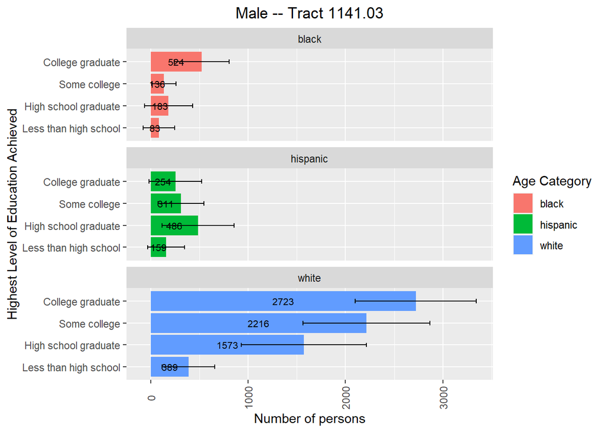

```r
dat <- ed %>%
  filter(tract == 1141.03) %>%
  filter(sex == 'Male') %>%
  filter(race %in% c('white', 'black', 'hispanic')) %>%
  filter(education != 'Total') %>%
  ungroup()


dat$education <- factor(dat$education,
                        levels=c('Less than high school',
                                 'High school graduate',
                                 'Some college',
                                 'College graduate'))

# stacked bar chart
ggplot(dat,
       aes(fill=race, y=estimate, x=education, label=estimate)) +
  geom_bar(position="stack", stat="identity") +
  geom_errorbar(aes(ymin = estimate - moe,
                    ymax = estimate + moe), width = 0.2) +
  geom_text(size = 2.8,
            position = position_stack(vjust = 0.5)) +
  facet_wrap(~race, ncol = 1) +
  coord_flip() +
  labs(
    x = 'Highest Level of Education Achieved',
    y = 'Number of persons',
    title = 'Male -- Tract 1141.03',
    fill = 'Age Category') +
  theme(axis.text.x = element_text(angle = 90, vjust = 0.5, hjust=0.5),
        plot.title = element_text(hjust = 0.5))
```

##### Proportions

What is the likelihood of educational attainment XXX for a “white” male residing in Census tract 1141.03 during 2019?

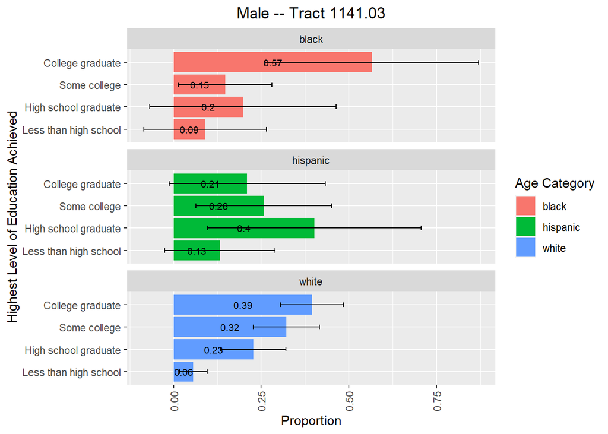

```r
# stacked bar chart
ggplot(dat,
       aes(fill=race, y=proportion, x=education, label=round(proportion, 2))) +
  geom_bar(position="stack", stat="identity") +
  geom_errorbar(aes(ymin = proportion - proportion_moe,
                    ymax = proportion + proportion_moe), width = 0.2) +
  geom_text(size = 2.8,
            position = position_stack(vjust = 0.5)) +
  facet_wrap(~race, ncol = 1) +
  coord_flip() +
  labs(
    x = 'Highest Level of Education Achieved',
    y = 'Proportion',
    title = 'Male -- Tract 1141.03',
    fill = 'Age Category') +
  theme(axis.text.x = element_text(angle = 90, vjust = 0.5, hjust=0.5),
        plot.title = element_text(hjust = 0.5))
```

#### Calculate the estimated probabilities

*First*, we snag the proportion of the population, in 2019 (in each Census tract, sex, and race) with each available category of “highest educational attainment”. High School education (highest attainment).

*Then*, we snag the proportion of the population (again, by Census tract, sex, and race) that fell into each available age category.

*Finally*, we obtain the estimated probability of education attainment level XXX by multiplying these probabilities (proportions).

```r
estimates <- ed %>%
  group_by(tract, sex, race, education) %>%
  summarise(num = sum(estimate)) %>%
  left_join(age %>%
              filter(agecat!='Total') %>%
              group_by(tract, sex, race) %>%
              summarize(denom = sum(estimate))
            ) %>%
  mutate(p = num/denom) %>%
  filter(education != 'Total') %>%
  ungroup()

# add probabilities for age categories, within (tract, sex, race)
q <- age %>%
  filter(agecat!='Total') %>%
  group_by(tract, agecat, sex, race) %>%
  summarize(n = sum(estimate)) %>%
  ungroup()

q <- tidyr::pivot_wider(q,
                   id_cols=c(tract, sex, race),
                   names_from=agecat,
                   names_prefix='age_',
                   names_repair='universal',
                   values_from=n)

estimates <- estimates %>%
  left_join(q) %>%
  # p = probability of educational attainment for (tract, sex, race)
  #     * probability of age-category for (tract, sex, race)
  mutate(age_25.29 = p*(age_25.29/denom),
         age_30.34 = p*(age_30.34/denom),
         age_35.44 = p*(age_35.44/denom),
         age_45.54 = p*(age_45.54/denom),
         age_55.64 = p*(age_55.64/denom),
         age_65.74 = p*(age_65.74/denom),
         age_75.84 = p*(age_75.84/denom),
         age_..85  = p*(age_..85/denom)
  )
```

#### Examples

##### Males

What is the likelihood of educational attainment XXX for a “white” male residing in Census tract 1141.03 during 2019 (given their age at run-time)?

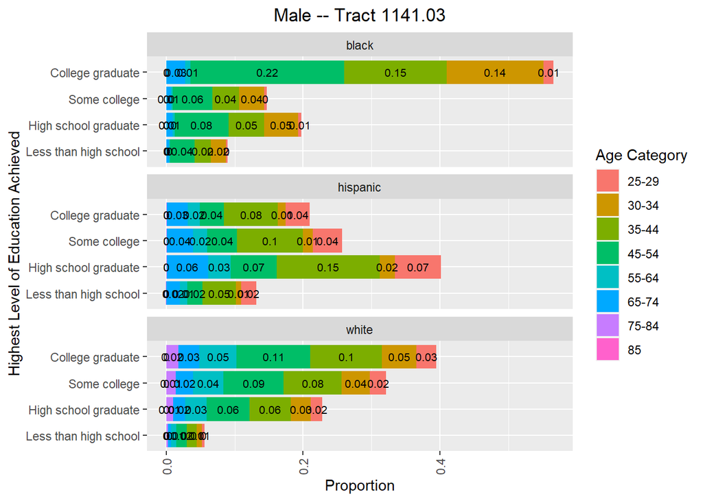

```r
# example
z <- estimates %>%
  filter(tract == 1141.03) %>%
  filter(sex == 'Male') %>%
  filter(race %in% c('white', 'black', 'hispanic')) %>%
  ungroup() %>%
  select(-c(tract, sex, num, denom, p))

#sum(z) == 1.0 ... sanity check!!

# pivot data for plotting
agefields <- z %>% select(-c(education, race)) %>% names()
dat <- tidyr::pivot_longer(z, cols=all_of(agefields))
dat <- dat %>%
  mutate(name = str_replace(name, '\\.\\.', ''),
         name = str_replace(name, 'age', ''),
         name = str_replace(name, '\\.', '-'),
         name = str_replace(name, '_', ''),
         name = as.factor(name))

dat$education <- factor(dat$education,
                        levels=c('Less than high school',
                                 'High school graduate',
                                 'Some college',
                                 'College graduate'))

# stacked bar chart
ggplot(dat,
       aes(fill=name, y=value, x=education, label=round(value, 2))) +
  geom_bar(position="stack", stat="identity") +
  geom_text(size = 2.8,
            position = position_stack(vjust = 0.5)) +
  facet_wrap(~race, ncol = 1) +
  coord_flip() +
  labs(
    x = 'Highest Level of Education Achieved',
    y = 'Proportion',
    title = 'Male -- Tract 1141.03',
    fill = 'Age Category') +
  theme(axis.text.x = element_text(angle = 90, vjust = 0.5, hjust=0.5),
        plot.title = element_text(hjust = 0.5))
```

**Notes** Appropriate margins of error, standard errors, and confidence intervals can be derived as described in the ACS handbook.

##### Females

What about for a female?

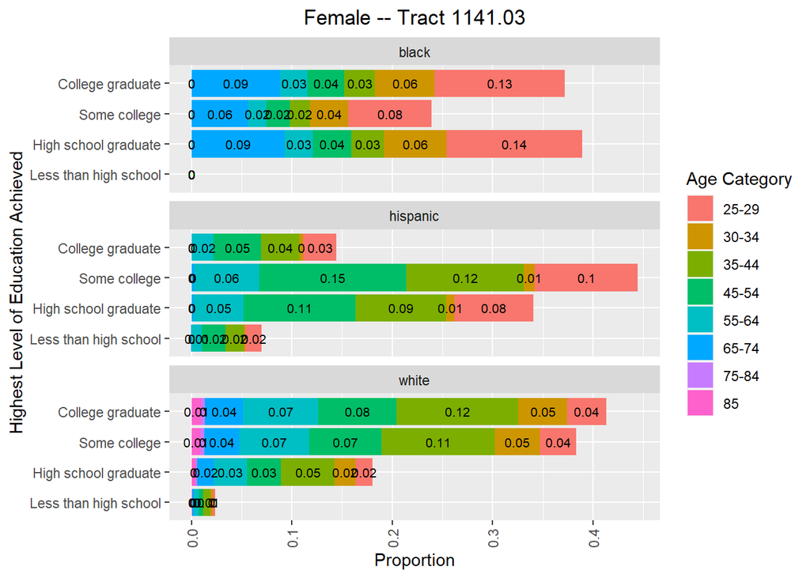

```r
# example
z <- estimates %>%
  filter(tract == 1141.03) %>%
  filter(sex == 'Female') %>%
  filter(race %in% c('white', 'black', 'hispanic')) %>%
  ungroup() %>%
  select(-c(tract, sex, num, denom, p))

#sum(z) == 1.0 ... sanity check!!

# pivot data for plotting
agefields <- z %>% select(-c(education, race)) %>% names()
dat <- tidyr::pivot_longer(z, cols=all_of(agefields))
dat <- dat %>%
  mutate(name = str_replace(name, '\\.\\.', ''),
         name = str_replace(name, 'age', ''),
         name = str_replace(name, '\\.', '-'),
         name = str_replace(name, '_', ''),
         name = as.factor(name))

dat$education <- factor(dat$education,
                        levels=c('Less than high school',
                                 'High school graduate',
                                 'Some college',
                                 'College graduate'))

# stacked bar chart
ggplot(dat,
       aes(fill=name, y=value, x=education, label=round(value, 2))) +
  geom_bar(position="stack", stat="identity") +
  geom_text(size = 2.8,
            position = position_stack(vjust = 0.5)) +
  facet_wrap(~race, ncol = 1) +
  coord_flip() +
  labs(
    x = 'Highest Level of Education Achieved',
    y = 'Proportion',
    title = 'Female -- Tract 1141.03',
    fill = 'Age Category') +
  theme(axis.text.x = element_text(angle = 90, vjust = 0.5, hjust=0.5),
        plot.title = element_text(hjust = 0.5))
```

**Notes** Appropriate margins of error, standard errors, and confidence intervals can be derived as described in the ACS handbook.

##### Validation

As a sanity check, see the [Census Reporter](https://censusreporter.org/profiles/14000US48439114103-census-tract-114103-tarrant-tx/).

#### Example using poverty status in the past 12 months

The data for these plots derives entirely from tables [B17001*](https://data.census.gov/cedsci/table?q=B17001).

##### Males

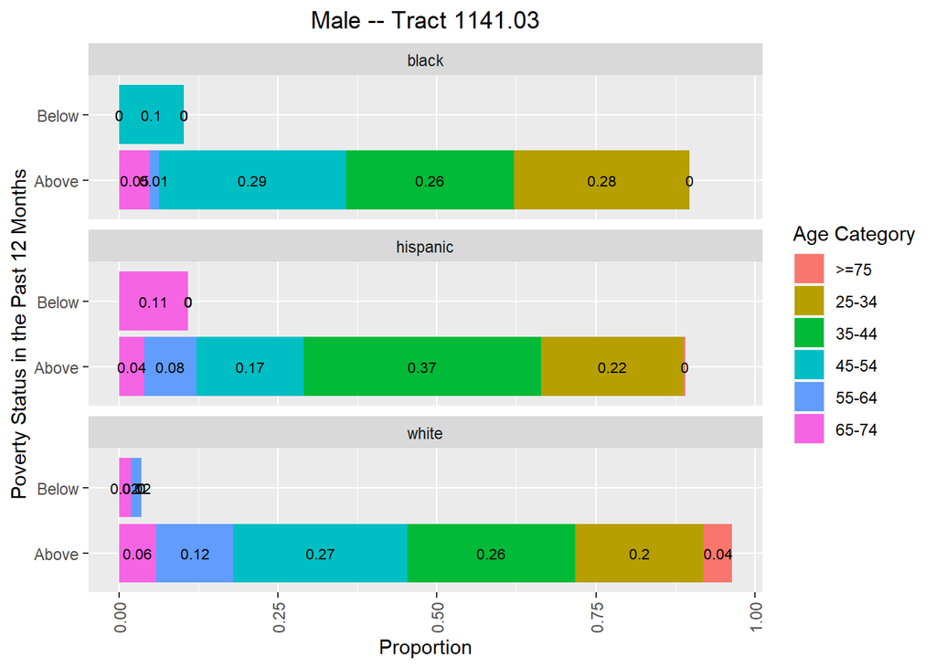

```r
dat <- pov %>%
  filter(poverty_status != 'Total') %>%
  # example data
  filter(tract == 1141.03) %>%
  filter(sex == 'Male') %>%
  filter(race %in% c('white', 'black', 'hispanic')) %>%
  filter(agecat != 'Total') %>%
  select(agecat, race, poverty_status, proportion, proportion_moe)


# stacked bar chart
ggplot(dat,
       aes(fill=agecat, y=proportion, x=poverty_status, label=round(proportion, 2))) +
  geom_bar(position="stack", stat="identity") +
  geom_text(size = 2.8,
            position = position_stack(vjust = 0.5)) +
  facet_wrap(~race, ncol = 1) +
  coord_flip() +
  labs(
    x = 'Poverty Status in the Past 12 Months',
    y = 'Proportion',
    title = 'Male -- Tract 1141.03',
    fill = 'Age Category') +
  theme(axis.text.x = element_text(angle = 90, vjust = 0.5, hjust=0.5),
        plot.title = element_text(hjust = 0.5))
```

**Notes** Appropriate margins of error, standard errors, and confidence intervals can be derived as described in the ACS handbook (the MOEs calculated, thus far, correctly account for the fact that ages < 25 years were left out … but they do **not** correctly account the the aggregation of estimates over poverty status).

##### Females

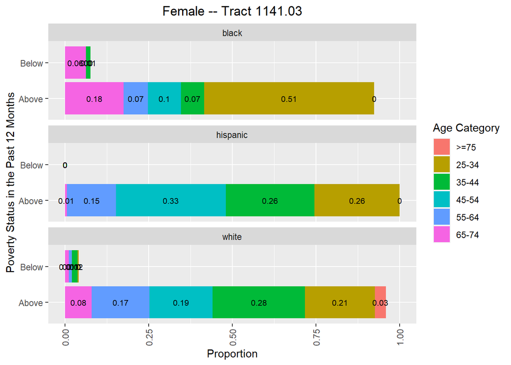

```r
dat <- pov %>%
  filter(poverty_status != 'Total') %>%
  # example data
  filter(tract == 1141.03) %>%
  filter(sex == 'Female') %>%
  filter(race %in% c('white', 'black', 'hispanic')) %>%
  filter(agecat != 'Total') %>%
  select(agecat, race, poverty_status, proportion, proportion_moe)


# stacked bar chart
ggplot(dat,
       aes(fill=agecat, y=proportion, x=poverty_status, label=round(proportion, 2))) +
  geom_bar(position="stack", stat="identity") +
  geom_text(size = 2.8,
            position = position_stack(vjust = 0.5)) +
  facet_wrap(~race, ncol = 1) +
  coord_flip() +
  labs(
    x = 'Poverty Status in the Past 12 Months',
    y = 'Proportion',
    title = 'Female -- Tract 1141.03',
    fill = 'Age Category') +
  theme(axis.text.x = element_text(angle = 90, vjust = 0.5, hjust=0.5),
        plot.title = element_text(hjust = 0.5))
```

**Notes** Appropriate margins of error, standard errors, and confidence intervals can be derived as described in the ACS handbook (the MOEs calculated, thus far, correctly account for the fact that ages < 25 years were left out … but they do **not** correctly account the the aggregation of estimates over poverty status).